# Coursera-Practical Machine Learning Project

Abdul Rasheed Narejo

06/09/2018

## About the assignment

Using devices such as Jawbone Up, Nike FuelBand, and Fitbit it is now possible to collect a large amount of data about personal activity relatively inexpensively. These type of devices are part of the quantified self movement – a group of enthusiasts who take measurements about themselves regularly to improve their health, to find patterns in their behavior, or because they are tech geeks. One thing that people regularly do is quantify how much of a particular activity they do, but they rarely quantify how well they do it. In this project, your goal will be to use data from accelerometers on the belt, forearm, arm, and dumbell of 6 participants. They were asked to perform barbell lifts correctly and incorrectly in 5 different ways.

## Goal

The goal of your project is to predict the manner in which they did the exercise. This is the “classe” variable in the training set. We may use any of the other variables to predict with. In the end, we will use the best prediction model to predict 20 different test cases.

## Loading libraries

```r
library(caret)
library(rattle)
library(rpart)
library(gbm)
library(randomForest)
library(class)
```

## loading data

The data for this assignment includes a separate training and testing data set. source: http://groupware.les.inf.puc-rio.br/har

```r
trainingInitial <- read.csv("data/pml-training.csv", na.strings=c("NA",""), header = TRUE)
dim(trainingInitial)
```

```
## [1] 19622   160
```

```r
testingFinal <- read.csv("data/pml-testing.csv", na.strings=c("NA",""), header=TRUE)
dim(testingFinal)
```

```
## [1]  20 160
```

**Note:** The testingFinal data frame is only going to be used for validation of final model/test. We will keep this aside.

## Cleaning the data

The training data has 19,622 observations for 160 different variables (columns). Some of these columns have significant percentage of NA/empty data. We will check for columns with significant missing values and remove them from the data.

We will also remove first 7 columns which are variables which will not be useful in predictive model building.

```r
# calculate percentage of missing values in each column
NaRatio <- apply(trainingInitial, 2, function(col)sum(is.na(col))/length(col))

# filter columns with missing values
# all columns with missing values have high ratio of missing values(95% plus)
df <- trainingInitial[,NaRatio == 0]

# remove columns 1:7 due to their lack of relevance in model developments
df <- df[,-c(1:7)]

# convert response/target variable as factor variable
df$classe <- as.factor(df$classe)
```

## Split df into Training and Testing Data for model creation/testing

We will subdivide our training data into training and testing data. For this we will split data into two parts, 70% training, 30% testing. We will use caret package function createDataPartition for this.

```r
set.seed(333)
inTrain <- createDataPartition(y = df$classe, p = 0.7, list = FALSE)
training <- df[inTrain,]
testing <- df[-inTrain,]
dim(training); dim(testing)
```

```
## [1] 13737    53
```

```
## [1] 5885   53
```

## Develop Machine Learning Models

Instead of using caret package, I have directly used specific library for each machine learning model due to lower complexity and higher visibility on inputs. Caret package considers some base level assumptions which significantly slow down the model while the output benefit is relatively hard to quantify.

For this project, I have found that using original libraries gives better understanding, relatively good performance and greater control of model working.

- Rpart
- Random forest
- Gradient Boosting Model

### 1. Recursive Partitioning - Rpart (Classification Tree)

```r
# create model
modelRP<- rpart(classe ~ ., data = training, method="class")
```

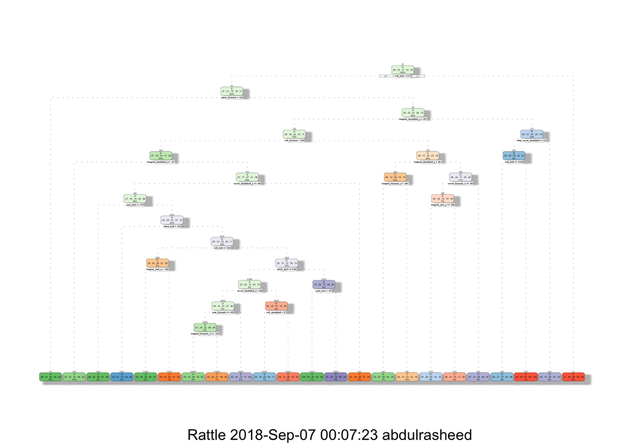

```r
fancyRpartPlot(modelRP)
```

```r
# Predicting the classe variables on testing dataset
predictRP <- predict(modelRP, newdata = testing, type="class")
```

```r
confMatrixRP <- confusionMatrix(testing$classe, predictRP)
confMatrixRP
```

```
## Confusion Matrix and Statistics
##
##           Reference
## Prediction    A    B    C    D    E
##          A 1544   34   52   19   25
##          B  207  623  172   79   58
##          C   15   89  824   67   31
##          D   94   37  155  619   59
##          E   33   78  135   68  768
##
## Overall Statistics
##
##                Accuracy : 0.7439
##                  95% CI : (0.7326, 0.755)
##     No Information Rate : 0.3217
##     P-Value [Acc > NIR] : < 2.2e-16
##
##                   Kappa : 0.6748
##  Mcnemar's Test P-Value : < 2.2e-16
##
## Statistics by Class:
##
##                      Class: A Class: B Class: C Class: D Class: E
## Sensitivity            0.8156   0.7236   0.6158   0.7265   0.8162
## Specificity            0.9674   0.8973   0.9556   0.9315   0.9365
## Pos Pred Value         0.9223   0.5470   0.8031   0.6421   0.7098
## Neg Pred Value         0.9171   0.9499   0.8942   0.9527   0.9640
## Prevalence             0.3217   0.1463   0.2274   0.1448   0.1599
## Detection Rate         0.2624   0.1059   0.1400   0.1052   0.1305
## Detection Prevalence   0.2845   0.1935   0.1743   0.1638   0.1839
## Balanced Accuracy      0.8915   0.8104   0.7857   0.8290   0.8763
```

Classification tree has generated accuracy of only 0.74 which is not bad for the start.

### 2. Random Forest

```r
# create model
modelRF <- randomForest(classe ~ ., data = training, ntree = 10)

# Predicting the classe variables on testing dataset
predictRF <- predict(modelRF, newdata = testing)
```

```r
confMatrixRF <- confusionMatrix(testing$classe, predictRF)
confMatrixRF
```

```
## Confusion Matrix and Statistics
##
##           Reference
## Prediction    A    B    C    D    E
##          A 1672    1    0    0    1
##          B    9 1125    4    0    1
##          C    0    8 1011    6    1
##          D    0    1   13  948    2
##          E    0    1    1    2 1078
##
## Overall Statistics
##
##                Accuracy : 0.9913
##                  95% CI : (0.9886, 0.9935)
##     No Information Rate : 0.2856
##     P-Value [Acc > NIR] : < 2.2e-16
##
##                   Kappa : 0.989
##  Mcnemar's Test P-Value : NA
##
## Statistics by Class:
##
##                      Class: A Class: B Class: C Class: D Class: E
## Sensitivity            0.9946   0.9903   0.9825   0.9916   0.9954
## Specificity            0.9995   0.9971   0.9969   0.9968   0.9992
## Pos Pred Value         0.9988   0.9877   0.9854   0.9834   0.9963
## Neg Pred Value         0.9979   0.9977   0.9963   0.9984   0.9990
## Prevalence             0.2856   0.1930   0.1749   0.1624   0.1840
## Detection Rate         0.2841   0.1912   0.1718   0.1611   0.1832
## Detection Prevalence   0.2845   0.1935   0.1743   0.1638   0.1839
## Balanced Accuracy      0.9971   0.9937   0.9897   0.9942   0.9973
```

Random forest model has generate a high level of accuracy of 0.99 which is nearly perfect. However, for sake of variety we will also use Gradient Boosting Model.

### 3. Gradient Boosting Model

```r
modelGbm <- gbm(classe ~ .,data=training,
         distribution='multinomial',
         n.trees=200,
         interaction.depth=5,
         #cv.folds=5,
         shrinkage=0.005)
```

```r
predictGbm <- predict(modelGbm, newdata = testing, n.trees=200, type="response")
pred_class <- apply(predictGbm, 1, which.max)
x <- colnames(predictGbm)[pred_class]
GbmAccuracy <- mean(x == testing$classe)
```

## Conclusion

```r
finalPrediction <- predict(modelRF, newdata = testingFinal)
finalPrediction
```

```
##  1  2  3  4  5  6  7  8  9 10 11 12 13 14 15 16 17 18 19 20
##  B  A  B  A  A  E  D  B  A  A  B  C  B  A  E  E  A  B  B  B
## Levels: A B C D E
```